# Model Results (STATs)

Min Hwangbo

December 5, 2018

```r
# Using these packages in this lecture
library("broom") #output list and grabs commonly used dataframes
library("ggeffects") #pllotting marginal effects (expected values over the range of other variables)
```

```r
library("pander") #regression tables
library("sjPlot") #sjPlot
library("tidyverse")
ex_dat <- data.frame(num1 = rnorm(200, 1, 2),
                     fac1 = sample(c(1, 2, 3), 200, TRUE),
                     num2 = rnorm(200, 0, 3),
                     fac2 = sample(c(1, 2))) %>%
  mutate(yn = num1*0.5 + fac1*1.1 + num2*0.7 + fac2-1.5  + rnorm(200, 0, 2)) %>%
  mutate(yb = as.numeric(yn > mean(yn))) %>%
  mutate(fac1 = factor(fac1, labels=c("A", "B", "C")),
         fac2 = factor(fac2, labels=c("Yes", "No")))
#framing data
```

# 1 `broom`

```r
#tidy(): dataframe summaries
#augment()
#glance()
```

## 1.1 `broom::tidy()`

```r
lm_1 <- lm(yn ~ num1 + fac1, data = ex_dat)
glm_1 <- glm(yb ~ num1 + fac1, data = ex_dat, family=binomial(link="logit"))
lm_1 %>% tidy()
```

```
## # A tibble: 4 x 5
##   term        estimate std.error statistic     p.value
##   <chr>          <dbl>     <dbl>     <dbl>       <dbl>
## 1 (Intercept)    1.31     0.374       3.50 0.000580
## 2 num1           0.517    0.0982      5.26 0.000000373
## 3 fac1B          1.15     0.516       2.23 0.0271
## 4 fac1C          1.93     0.497       3.89 0.000135
```

```r
glm_1 %>% tidy()
```

```
## # A tibble: 4 x 5
##   term        estimate std.error statistic  p.value
##   <chr>          <dbl>     <dbl>     <dbl>    <dbl>
## 1 (Intercept)   -0.943    0.291      -3.24 0.00120
## 2 num1           0.320    0.0825      3.88 0.000106
## 3 fac1B          0.592    0.383       1.55 0.122
## 4 fac1C          1.36     0.378       3.59 0.000334
```

## 1.2 `broom::glance()`

```r
glance(lm_1)
```

```
## # A tibble: 1 x 11
##   r.squared adj.r.squared sigma statistic p.value    df logLik   AIC   BIC
## *     <dbl>         <dbl> <dbl>     <dbl>   <dbl> <int>  <dbl> <dbl> <dbl>
## 1     0.185         0.173  2.89      14.9 9.17e-9     4  -494.  999. 1015.
## # ... with 2 more variables: deviance <dbl>, df.residual <int>
```

## 1.3 `broom::augment()`

```r
augment(lm_1) %>% head()
```

```
## # A tibble: 6 x 10
##        yn   num1 fac1  .fitted .se.fit .resid   .hat .sigma .cooksd
##     <dbl>  <dbl> <fct>   <dbl>   <dbl>  <dbl>  <dbl>  <dbl>   <dbl>
## 1 -0.120   1.16  A       1.91    0.366 -2.03  0.0160   2.90 2.02e-3
## 2  0.193  -0.788 C       2.83    0.381 -2.64  0.0173   2.90 3.73e-3
## 3 -0.0699  2.29  C       4.42    0.358 -4.49  0.0153   2.88 9.51e-3
## 4  1.77   -1.29  A       0.642   0.419  1.13  0.0210   2.90 8.30e-4
## 5  3.97    2.73  B       3.86    0.414  0.108 0.0204   2.90 7.35e-6
## 6  5.29    1.24  A       1.95    0.367  3.34  0.0161   2.89 5.52e-3
## # ... with 1 more variable: .std.resid <dbl>
```

## 1.4 The Power of broom

```r
#do() repeats whatever is inside it once for each level of the variable(s) in group_by() then puts them together as a data frame.
ex_dat %>% group_by(fac1) %>% do(tidy(lm(yn ~  num1 + fac2 + num2, data = ex_dat)))
```

```
## # A tibble: 12 x 6
## # Groups:   fac1 [3]
##    fac1  term        estimate std.error statistic  p.value
##    <fct> <chr>          <dbl>     <dbl>     <dbl>    <dbl>
##  1 A     (Intercept)    2.07     0.231       8.95 2.79e-16
##  2 A     num1           0.542    0.0757      7.15 1.64e-11
##  3 A     fac2No         0.508    0.318       1.60 1.12e- 1
##  4 A     num2           0.675    0.0551     12.3  5.00e-26
##  5 B     (Intercept)    2.07     0.231       8.95 2.79e-16
##  6 B     num1           0.542    0.0757      7.15 1.64e-11
##  7 B     fac2No         0.508    0.318       1.60 1.12e- 1
##  8 B     num2           0.675    0.0551     12.3  5.00e-26
##  9 C     (Intercept)    2.07     0.231       8.95 2.79e-16
## 10 C     num1           0.542    0.0757      7.15 1.64e-11
## 11 C     fac2No         0.508    0.318       1.60 1.12e- 1
## 12 C     num2           0.675    0.0551     12.3  5.00e-26
```

```r
#subgroup or national data sets overview
```

# 2 `ggeffects`

- Vocabs!
- When we set variables to certain values, we refer to them as counterfactual values or just counterfactuals.
- For example, if we know nothing about a new observation, our prediction for that estimate is often based on assuming every variable is at its mean.
- Sometimes, however, we might have very specific questions which require setting (possibly many) combinations of variables to particular values and making an estimate or prediction.
- Providing specific estimates, conditional on values of covariates, is a nice way to summarize results, particularly for models with unintuitive parameters (e.g. logit models).

## 2.1 `ggeffects`packets

- Tidyframe
- Ranges of predictive values
- `ggpredicts()` - Computes predicted values for the outcome variable (Y) at margins of specific variables (X1 or X2).
- `plot.ggeffects()` - A plot method for ggeffects objects (like `ggredict()` output)

## 2.2 `ggpredict()`

- One predictor using the terms argument

```r
lm_1_est<- ggpredict(lm_1, terms = "num1")
lm_1_est
```

```
##
## # Predicted values of yn
## # x = num1
##
##   x predicted std.error conf.low conf.high
##  -6    -1.794     0.763   -3.290    -0.299
##  -4    -0.761     0.598   -1.933     0.411
##  -2     0.273     0.458   -0.625     1.171
##   0     1.307     0.374    0.574     2.039
##   2     2.340     0.383    1.590     3.090
##   4     3.374     0.480    2.433     4.315
##   6     4.407     0.626    3.181     5.634
##   8     5.441     0.794    3.886     6.997
##
## Adjusted for:
## * fac1 = A
```

## 2.3 `plot()` for `ggpredict()`

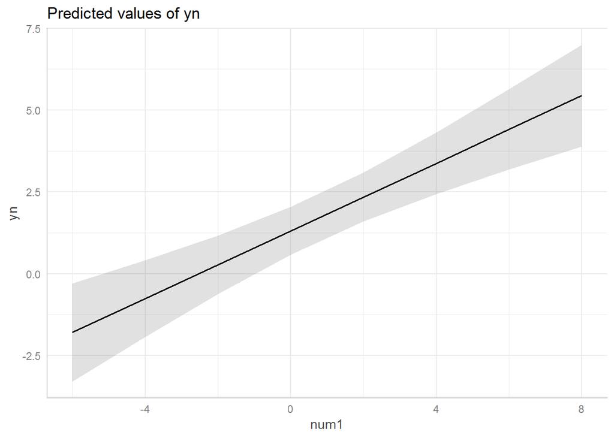

```r
plot(lm_1_est)
```

## 2.4 Grouping with `ggpredict()`

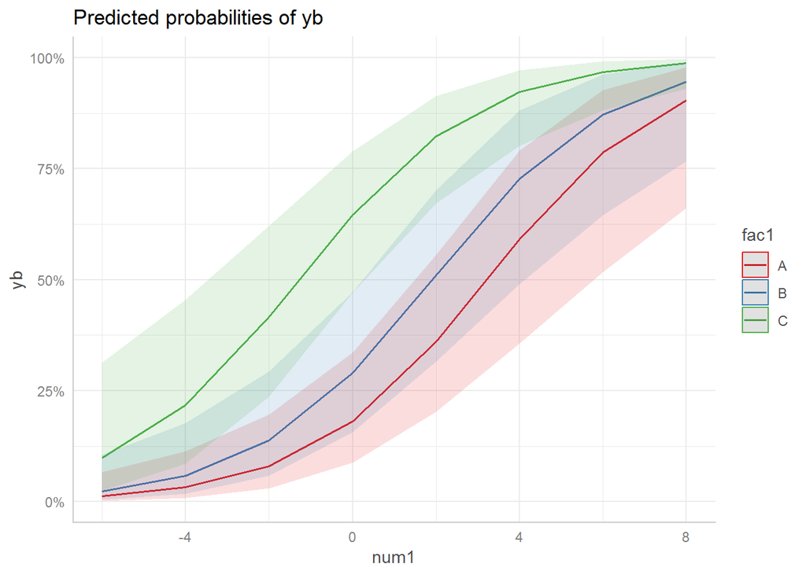

```r
glm(yb ~ num1 + fac1 + num2 + fac2, data = ex_dat, family=binomial(link = "logit")) %>%
  ggpredict(terms = c("num1", "fac1")) %>% plot()
```

## 2.5 Faceting with `ggpredict()`

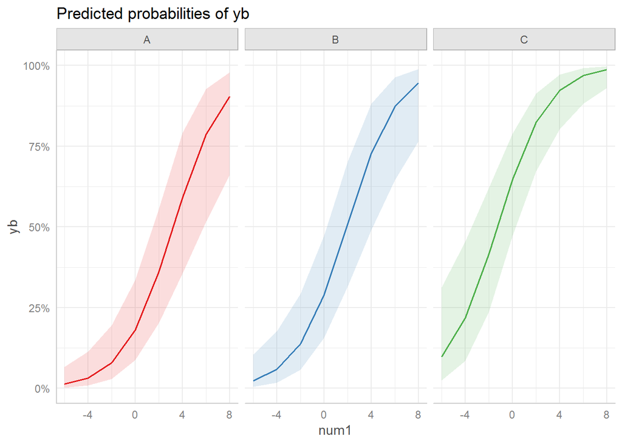

```r
glm(yb ~ num1 + fac1 + num2 + fac2, data = ex_dat, family = binomial(link = "logit")) %>%
  ggpredict(terms = c("num1", "fac1")) %>% plot(facet=TRUE)
```

## 2.6 Counterfactual Values using `terms=`

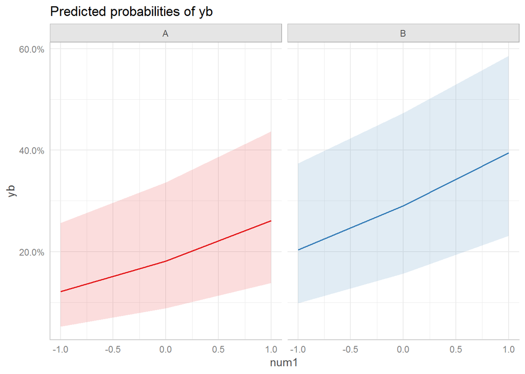

```r
glm(yb ~ num1 + fac1 + num2 + fac2, data=ex_dat, family=binomial(link="logit")) %>%
ggpredict(terms = c("num1 [-1,0,1]", "fac1 [A,B]")) %>% plot(facet=TRUE)
```

## 2.7 Representative Values using `[meansd]` or `[minmax]`

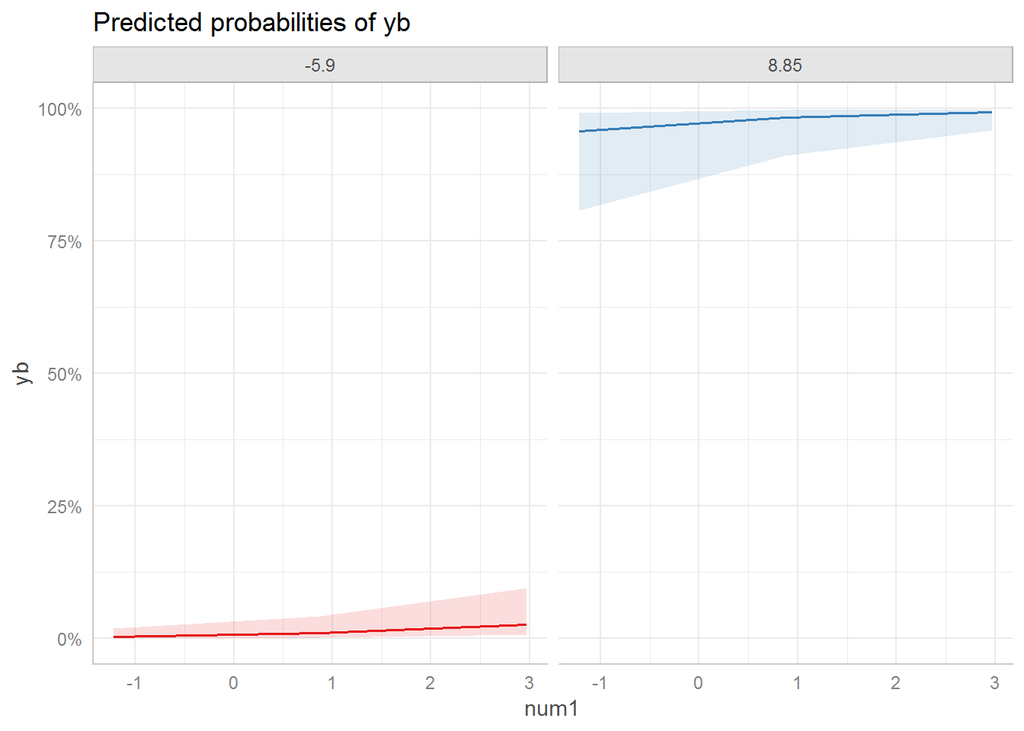

```r
glm(yb ~ num1 + fac1 + num2 + fac2, data = ex_dat, family = binomial(link = "logit")) %>%
  ggpredict(terms = c("num1 [meansd]", "num2 [minmax]")) %>% plot(facet=TRUE)
```

```r
#exploratory visual of a model
```

## 2.8 Dot plots with `ggpredict()`

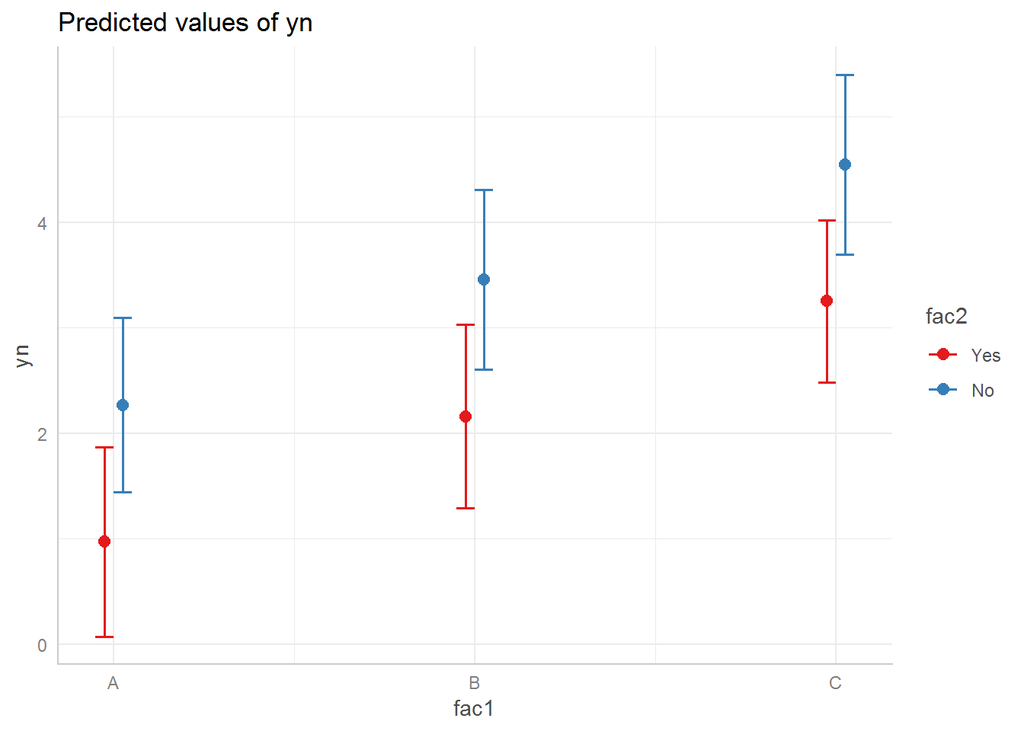

```r
lm(yn ~ fac1 + fac2, data = ex_dat) %>%
  ggpredict(terms=c("fac1", "fac2")) %>% plot()
```

## 2.9 Notes on `ggeffects()`

There is a lot more to the `ggeffects` package that you can see in the package vignette and the github repository. This includes, but is not limited to:

- Predicted values for polynomial and interaction terms
- Getting predictions from models from dozens of other packages
- Sending `ggeffects` objects to `ggplot2` to freely modify plots

# 3 Advanced Examples

- Read this: https://onlinelibrary.wiley.com/doi/full/10.1111/cico.12346
- Interactions going on ** Target Race x Caller Race ** Crime Type x Caller Race ** Target Race x Neigbhorhood Type ** Crime Type x Neighborhood Type

```r
load("data/any_arrest_data.RData")
mod_arrest <- glm(arrest ~ white_comp_wit_vict*black_arr_susp +
                  crime_type*white_comp_wit_vict + caller_type +
                  arr_susp_subj_count + comp_wit_vict_count +
                  black_arr_susp*neighb_type + crime_type*neighb_type +
                  serious_rate + pbl + pot + dis + year,
                  family = binomial(link = "logit"),
                  data = any_arrest_data)
```

## 3.1 Bootstrapping

- Page 27

## 3.2 Simulating Coefficients

```r
sim_params <- MASS::mvrnorm(n = 10000,
                            mu = coef(mod_arrest),
                            Sigma = vcov(mod_arrest))
sim_params[1:6, 1:4]
```

## 3.3 Counterfactual Values

```r
x_values <- colMeans(model.matrix(mod_arrest)) # vars at mean
n_scen   <- (2*2*2*3) # Number of scenarios
x_frame  <- setNames(data.frame(matrix(x_values, nrow=n_scen,
                                       ncol=length(x_values),
                                       byrow=T)), names(x_values))
cf_vals  <- arrangements::permutations(c(0,1), k=5, replace=T)
cf_vals  <- cf_vals[cf_vals[,4]+cf_vals[,5]!=2 ,] # Remove impossible vals
colnames(cf_vals) <- c("white_comp_wit_vict1", "black_arr_susp1",
                       "crime_typeNuisance", "neighb_typeBlackDisadv",
                       "neighb_typeChanging")
x_frame[colnames(cf_vals)] <- cf_vals # assign to countefactual df
```

### 3.3.1 What do we have?

```r
glimpse(x_frame)
x_frame <- x_frame %>%
 mutate(
  `white_comp_wit_vict1:black_arr_susp1`      = white_comp_wit_vict1*black_arr_susp1,
  `white_comp_wit_vict1:crime_typeNuisance`   = white_comp_wit_vict1*crime_typeNuisance,
  `black_arr_susp1:neighb_typeBlackDisadv`    = black_arr_susp1*neighb_typeBlackDisadv,
  `black_arr_susp1:neighb_typeChanging`       = black_arr_susp1*neighb_typeChanging,
  `crime_typeNuisance:neighb_typeBlackDisadv` = crime_typeNuisance*neighb_typeBlackDisadv,
  `crime_typeNuisance:neighb_typeChanging`    = crime_typeNuisance*neighb_typeChanging,
  `black_arr_susp1:neighb_typeBlackDisadv`    = black_arr_susp1*neighb_typeBlackDisadv,
  `black_arr_susp1:neighb_typeChanging`       = black_arr_susp1*neighb_typeChanging)
#Let's fix this
glimpse(x_frame)
#Fixed
```

### 3.3.2 Estimates!

```r
sims_logodds <- sim_params %*% t(as.matrix(x_frame))
sims_logodds[1:6, 1:6]
dim(sims_logodds)
```

### 3.3.3 Probabilities

```r
sims_prob    <- exp(sims_logodds) / (1 + exp(sims_logodds))
sims_prob[1:6, 1:6]
extract_pe_ci <- function(x){
  vals <- c(mean(x), quantile(x, probs=c(.025, .975)))
  names(vals) <- c("PE", "LB", "UB")
  return(vals)
}
```

### 3.3.4 Prep for Plotting

```r
estimated_pes <- as.data.frame( t(apply(sims_prob, 2, extract_pe_ci)))
estimated_pes$`Reporter`     <- ifelse(cf_vals[,1]==1, "Any White", "All Black")
estimated_pes$`Target`       <- ifelse(cf_vals[,2]==1, "Any Black", "All White")
estimated_pes$`Crime Type`   <- ifelse(cf_vals[,3]==1, "Nuisance Crime", "Serious Crime")
estimated_pes$`Neighborhood` <- case_when(
  cf_vals[,4]==1 ~ "Disadvantaged",
  cf_vals[,5]==1 ~ "Changing",
  TRUE ~ "Stable White")
```

### 3.3.5 Clean data

```r
estimated_pes %>% mutate_if(is.numeric, round, digits=3) # round for display
```

### 3.3.6 Plotting Codes!

```r
ggplot(estimated_pes, aes(x = Target, y = PE, group = Reporter)) +
  facet_grid(`Crime Type` ~ Neighborhood) +
  geom_errorbar(aes(ymin = LB, ymax = UB),
                position = position_dodge(width = .4),
                size = 0.75, width = 0.15) +
  geom_point(shape = 21, aes(fill = Reporter),
             position = position_dodge(width = .4),
             size = 2) +
  scale_fill_manual("Reporter", values=c("Any White" = "white",
                                         "All Black" = "black")) +
  ggtitle("Figure 3. Probability of Arrest",
      subtitle = "by Reporter and Target Race, Neighborhood and Crime Type") +
  xlab("Race of Target") + ylab("Estimated Probability") +
  theme_bw() + theme(legend.position = c(0.86,0.15),
                     legend.background = element_rect(color = 1))
```

# 4 `sjPlot`

- html table

## 4.1 `sjPlot`Tables

```r
model_1 <- lm(mpg ~ wt, data = mtcars)
tab_model(model_1)
```

|  | mpg |  |  |
| --- | --- | --- | --- |
| Predictors | Estimates | CI | p |
| (Intercept) | 37.29 | 33.61 – 40.97 | **<0.001** |
| wt | -5.34 | -6.44 – -4.25 | **<0.001** |
| Observations | 32 |  |  |
| R<sup>2</sup> / adjusted R<sup>2</sup> | 0.753 / 0.745 |  |  |

```r
#Multi model tables
model_2 <- lm(mpg ~ hp + wt, data = mtcars)
model_3 <- lm(mpg ~ hp + wt + factor(am), data = mtcars)
tab_model(model_1, model_2, model_3)
```

|  | mpg |  |  | mpg |  |  | mpg |  |  |
| --- | --- | --- | --- | --- | --- | --- | --- | --- | --- |
| Predictors | Estimates | CI | p | Estimates | CI | p | Estimates | CI | p |
| (Intercept) | 37.29 | 33.61 – 40.97 | **<0.001** | 37.23 | 34.09 – 40.36 | **<0.001** | 34.00 | 28.82 – 39.18 | **<0.001** |
| wt | -5.34 | -6.44 – -4.25 | **<0.001** | -3.88 | -5.12 – -2.64 | **<0.001** | -2.88 | -4.65 – -1.10 | **0.004** |
| hp |  |  |  | -0.03 | -0.05 – -0.01 | **0.001** | -0.04 | -0.06 – -0.02 | **0.001** |
| factor(am)1 |  |  |  |  |  |  | 2.08 | -0.61 – 4.78 | 0.141 |
| Observations | 32 |  |  | 32 |  |  | 32 |  |  |
| R<sup>2</sup> / adjusted R<sup>2</sup> | 0.753 / 0.745 |  |  | 0.827 / 0.815 |  |  | 0.840 / 0.823 |  |  |

# 5 `corrplot`

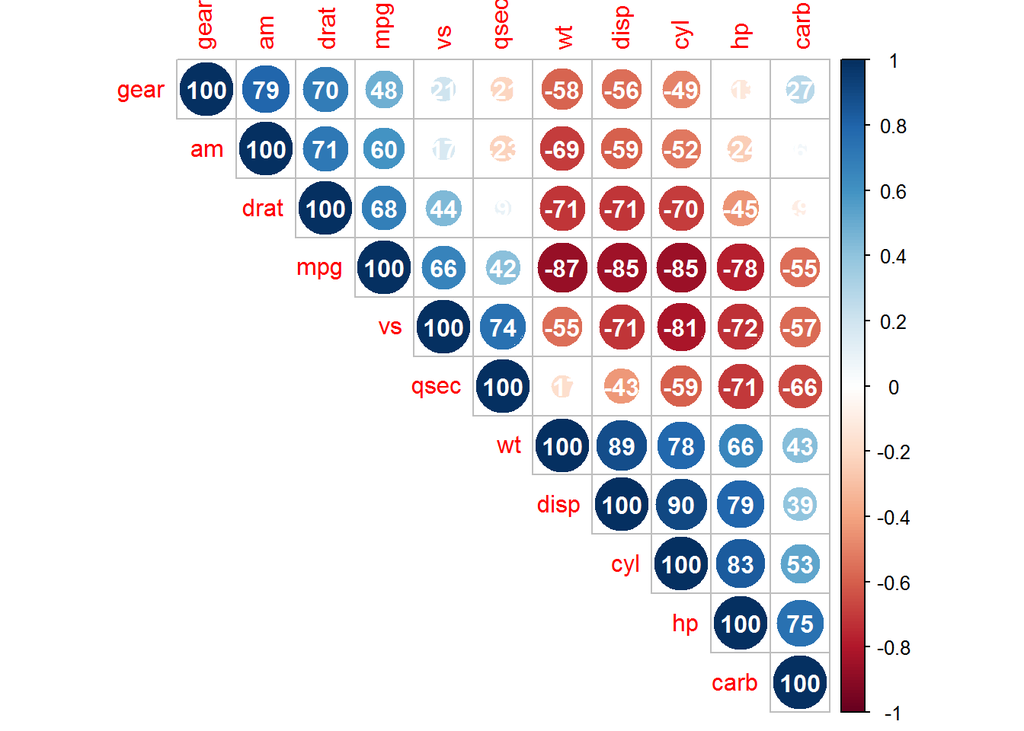

```r
library(corrplot)
corrplot(
  cor(mtcars),
  addCoef.col = "white",
  addCoefasPercent=T,
  type="upper",
  order="AOE")
```

# 6 Wrap Up

## 6.1 What did I learn?

- How to get data into R from a variety of formats
- How to do “data custodian” work to manipulate and clean data
- How to make pretty visualizations
- How to automate with loops and functions
- How to combine text, calculations, plots, and tables into dynamic R Markdown reports
- How to acquire and work with spatial data
- How to visualize a model result

## 6.2 What’s next?

- Stats inference

Functions for hypothesis testing, hierarchical/mixed effect models, machine learning, survey design, etc. are straightforward to use… once data are clean

- Practice

Replicate analyses you’ve done in Excel, SPSS, or Stata

- Project management

Using version control (git) in RStudio

Interactive Shiny web apps

Write your own functions and put them in a package